# ESM 244 Lab 7: Working with spatial data

Authors

Nathan Grimes

Yutian Fang

Casey O’Hara

Allison Horst

```r
library(tidyverse)
library(here)
library(broom)

# Spatial data packages
library(sf)
library(tmap)
```

# 1 Overview: Spatial data wrangling and visualization

In this week’s lecture, we learned a bit about projection and coordinate reference systems, types of spatial data, and investigating spatial autocorrelation using *variograms*. In this first part of lab we’ll practice working with spatial data, then move on to variograms and spatial interpolation in the next part. We’ll look at point pattern analysis (exploring spatial clustering) next week.

Today, we’ll use vector data (polygons, points) to practice reading in spatial data, checking & updating the CRS, and doing some wrangling and visualization.

We’ll use several datasets:

- California County shapefile (ca_counties_tiger_2016.shp) from the US Census Bureau’s 2016 MAF/TIGER database (accessed [here](https://data.ca.gov/dataset/ca-geographic-boundaries/resource/b0007416-a325-4777-9295-368ea6b710e6?inner_span=True))
- Red sesbania records (invasive species) from the CA DFW (accessed [here](https://map.dfg.ca.gov/metadata/ds0080.html))

## 1.1 California county outlines (polygons)

### 1.1.1 Read it in with `read_sf`

First, let’s read in the California county shapefile:

```r
ca_counties_raw_sf <- read_sf(here("data", "ca_counties", "CA_Counties_TIGER2016.shp"))
```

Note we only have to point to the .shp file, not all the others that are related.

## 1.2 Do a bit of wrangling

Use `View(ca_counties)` to check out what it contains. Let’s simplify it by first converting area to km<sup>2</sup> instead of m<sup>2</sup>, then only keeping county name and area.

All `tidyverse` and `dplyr` functions work the same as before!

```r
ca_counties_sf <- ca_counties_raw_sf %>%
  janitor::clean_names() %>%
  mutate(land_km2 = aland / 1e6) %>%
  select(county = name, land_km2)

head(ca_counties_sf)
```

```
Simple feature collection with 6 features and 2 fields
Geometry type: MULTIPOLYGON
Dimension:     XY
Bounding box:  xmin: -13565690 ymin: 3862173 xmax: -13096340 ymax: 4833572
Projected CRS: WGS 84 / Pseudo-Mercator
# A tibble: 6 × 3
  county        land_km2                                                geometry
  <chr>            <dbl>                                      <MULTIPOLYGON [m]>
1 Sierra           2469. (((-13431320 4821511, -13431313 4821520, -13431300 482…
2 Sacramento       2499. (((-13490651 4680832, -13490511 4680817, -13490465 468…
3 Santa Barbara    7084. (((-13423117 4042044, -13423158 4043249, -13422800 404…
4 Calaveras        2642. (((-13428575 4627725, -13428535 4627889, -13428535 462…
5 Ventura          4773. (((-13317854 3931602, -13317828 3932624, -13317686 393…
6 Los Angeles     10511. (((-13210018 3958856, -13210085 3959984, -13209920 396…
```

Take a look at `ca_counties_sf`. We should notice something very important about a simple features (sf) object: it just **assumes** you want to keep the spatial information, and you can work with the rest of the data as if it’s a non-spatial data frame (and the spatial information just “sticks” - hence the term “sticky geometry”). So even though we only called (and renamed) `name` and `aland` in the `select()` function, we see that the `geometry` column still exists!

What if we wanted just the dataframe, without the geometry? Convert to dataframe and select out the geometry column:

```r
ca_counties_df <- ca_counties_sf %>%
  as.data.frame() %>%
  select(-geometry)
```

## 1.3 Check and set the CRS

Use `st_crs()` to check the existing CRS for spatial data. We see that this CRS is “pseudo-mercator” based on WGS 84 - primarily used for web mapping, not analysis. WGS84 (epsg:3857), also note proj4 string and WKT definitions.

```r
ca_counties_sf %>% st_crs()
```

```
Coordinate Reference System:
  User input: WGS 84 / Pseudo-Mercator
  wkt:
PROJCRS["WGS 84 / Pseudo-Mercator",
    BASEGEOGCRS["WGS 84",
        ENSEMBLE["World Geodetic System 1984 ensemble",
            MEMBER["World Geodetic System 1984 (Transit)"],
            MEMBER["World Geodetic System 1984 (G730)"],
            MEMBER["World Geodetic System 1984 (G873)"],
            MEMBER["World Geodetic System 1984 (G1150)"],
            MEMBER["World Geodetic System 1984 (G1674)"],
            MEMBER["World Geodetic System 1984 (G1762)"],
            MEMBER["World Geodetic System 1984 (G2139)"],
            MEMBER["World Geodetic System 1984 (G2296)"],
            ELLIPSOID["WGS 84",6378137,298.257223563,
                LENGTHUNIT["metre",1]],
            ENSEMBLEACCURACY[2.0]],
        PRIMEM["Greenwich",0,
            ANGLEUNIT["degree",0.0174532925199433]],
        ID["EPSG",4326]],
    CONVERSION["Popular Visualisation Pseudo-Mercator",
        METHOD["Popular Visualisation Pseudo Mercator",
            ID["EPSG",1024]],
        PARAMETER["Latitude of natural origin",0,
            ANGLEUNIT["degree",0.0174532925199433],
            ID["EPSG",8801]],
        PARAMETER["Longitude of natural origin",0,
            ANGLEUNIT["degree",0.0174532925199433],
            ID["EPSG",8802]],
        PARAMETER["False easting",0,
            LENGTHUNIT["metre",1],
            ID["EPSG",8806]],
        PARAMETER["False northing",0,
            LENGTHUNIT["metre",1],
            ID["EPSG",8807]]],
    CS[Cartesian,2],
        AXIS["easting (X)",east,
            ORDER[1],
            LENGTHUNIT["metre",1]],
        AXIS["northing (Y)",north,
            ORDER[2],
            LENGTHUNIT["metre",1]],
    USAGE[
        SCOPE["Web mapping and visualisation."],
        AREA["World between 85.06°S and 85.06°N."],
        BBOX[-85.06,-180,85.06,180]],
    ID["EPSG",3857]]
```

## 1.4 Explore it visually

Plot the California counties using `geom_sf()`. Notice that we can update aesthetics just like we would for a regular ggplot object. Here, we update the color based on land area (and change the color gradient).

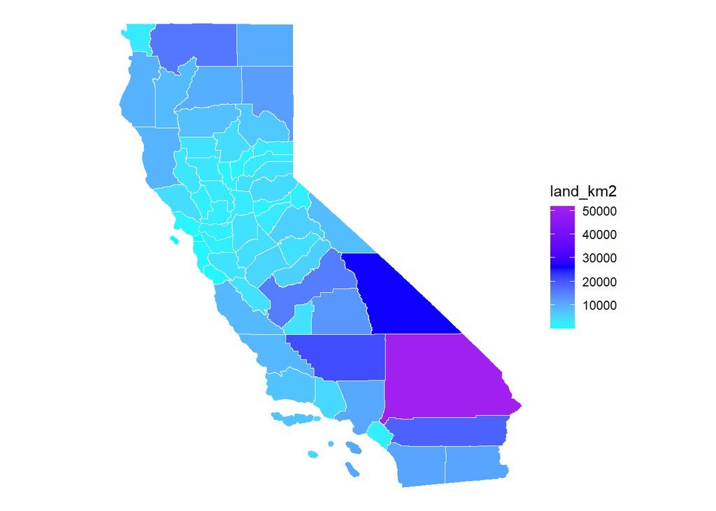

```r
ggplot(data = ca_counties_sf) +
  geom_sf(aes(fill = land_km2), color = "white", size = 0.1) +
  theme_void() +
  scale_fill_gradientn(colors = c("cyan","blue","purple"))
```

Notice what aesthetics we *didn’t* have to specify here?

`geom_sf` knows to look for a column called `geometry` (or sometimes `geom`).

# 2 Invasive red sesbania records (spatial points)

## 2.1 Read in the sesbania data

The data exist in `data/red_sesbania`, and the shapefile is stored as `ds80_for_lab.gpkg`. We also want to check the coordinate reference system, and plot the data for a quick visual understanding.

```r
sesbania_sf <- read_sf(here("data","red_sesbania","ds80_for_lab.gpkg")) %>%
  janitor::clean_names()

# Check the CRS:
sesbania_sf %>% st_crs()
```

```
Coordinate Reference System:
  User input: Custom
  wkt:
PROJCRS["Custom",
    BASEGEOGCRS["NAD83",
        DATUM["North American Datum 1983",
            ELLIPSOID["GRS 1980",6378137,298.257222101,
                LENGTHUNIT["metre",1]]],
        PRIMEM["Greenwich",0,
            ANGLEUNIT["Degree",0.0174532925199433]],
        ID["EPSG",4269]],
    CONVERSION["unnamed",
        METHOD["Albers Equal Area",
            ID["EPSG",9822]],
        PARAMETER["Latitude of false origin",0,
            ANGLEUNIT["Degree",0.0174532925199433],
            ID["EPSG",8821]],
        PARAMETER["Longitude of false origin",-120,
            ANGLEUNIT["Degree",0.0174532925199433],
            ID["EPSG",8822]],
        PARAMETER["Latitude of 1st standard parallel",34,
            ANGLEUNIT["Degree",0.0174532925199433],
            ID["EPSG",8823]],
        PARAMETER["Latitude of 2nd standard parallel",40.5,
            ANGLEUNIT["Degree",0.0174532925199433],
            ID["EPSG",8824]],
        PARAMETER["Easting at false origin",0,
            LENGTHUNIT["metre",1],
            ID["EPSG",8826]],
        PARAMETER["Northing at false origin",-4000000,
            LENGTHUNIT["metre",1],
            ID["EPSG",8827]]],
    CS[Cartesian,2],
        AXIS["easting",east,
            ORDER[1],
            LENGTHUNIT["metre",1,
                ID["EPSG",9001]]],
        AXIS["northing",north,
            ORDER[2],
            LENGTHUNIT["metre",1,
                ID["EPSG",9001]]]]
```

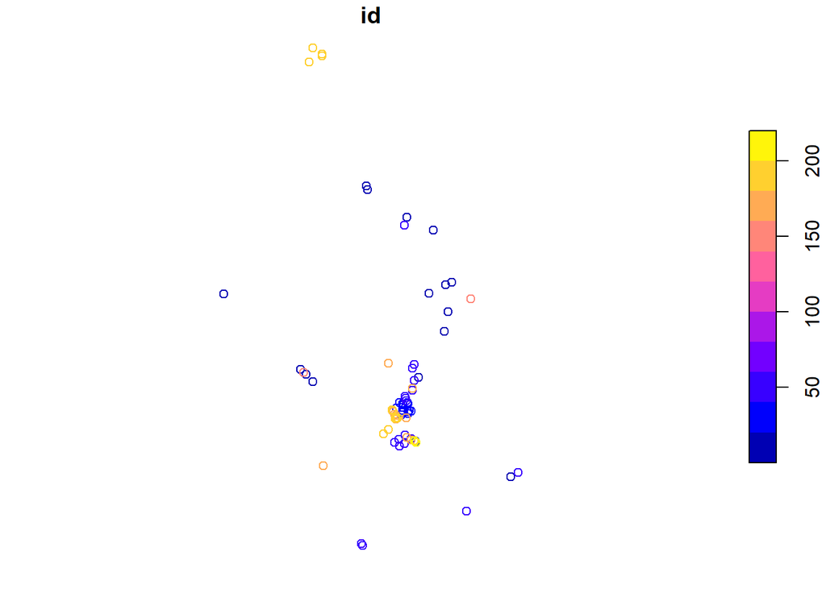

```r
plot(sesbania_sf %>% select(id))
```

## 2.2 The analysis:

Let’s say we want to find the count of red sesbania observed locations in this dataset *by county*. We then want to create a map of all CA counties using fill color to indicate sesbania counts.

Write pseudocode to accomplish this.

### 2.2.1 Pseudocode

## 2.3 Transform CRS so records match counties

Notice that this CRS is different from the California counties CRS, so we’ll want to update it to match. Use `st_transform()` to update the CRS:

```r
### if you know the EPSG code:
sesbania_3857_sf <- st_transform(sesbania_sf, 3857)
### if you don't know the EPSG code:
sesbania_3857_2_sf <- st_transform(sesbania_sf, st_crs(ca_counties_sf))

# Then check it:
sesbania_3857_sf %>% st_crs()
```

```
Coordinate Reference System:
  User input: EPSG:3857
  wkt:
PROJCRS["WGS 84 / Pseudo-Mercator",
    BASEGEOGCRS["WGS 84",
        ENSEMBLE["World Geodetic System 1984 ensemble",
            MEMBER["World Geodetic System 1984 (Transit)"],
            MEMBER["World Geodetic System 1984 (G730)"],
            MEMBER["World Geodetic System 1984 (G873)"],
            MEMBER["World Geodetic System 1984 (G1150)"],
            MEMBER["World Geodetic System 1984 (G1674)"],
            MEMBER["World Geodetic System 1984 (G1762)"],
            MEMBER["World Geodetic System 1984 (G2139)"],
            MEMBER["World Geodetic System 1984 (G2296)"],
            ELLIPSOID["WGS 84",6378137,298.257223563,
                LENGTHUNIT["metre",1]],
            ENSEMBLEACCURACY[2.0]],
        PRIMEM["Greenwich",0,
            ANGLEUNIT["degree",0.0174532925199433]],
        ID["EPSG",4326]],
    CONVERSION["Popular Visualisation Pseudo-Mercator",
        METHOD["Popular Visualisation Pseudo Mercator",
            ID["EPSG",1024]],
        PARAMETER["Latitude of natural origin",0,
            ANGLEUNIT["degree",0.0174532925199433],
            ID["EPSG",8801]],
        PARAMETER["Longitude of natural origin",0,
            ANGLEUNIT["degree",0.0174532925199433],
            ID["EPSG",8802]],
        PARAMETER["False easting",0,
            LENGTHUNIT["metre",1],
            ID["EPSG",8806]],
        PARAMETER["False northing",0,
            LENGTHUNIT["metre",1],
            ID["EPSG",8807]]],
    CS[Cartesian,2],
        AXIS["easting (X)",east,
            ORDER[1],
            LENGTHUNIT["metre",1]],
        AXIS["northing (Y)",north,
            ORDER[2],
            LENGTHUNIT["metre",1]],
    USAGE[
        SCOPE["Web mapping and visualisation."],
        AREA["World between 85.06°S and 85.06°N."],
        BBOX[-85.06,-180,85.06,180]],
    ID["EPSG",3857]]
```

Cool, now they have the same CRS.

### 2.3.1 Plot them together!

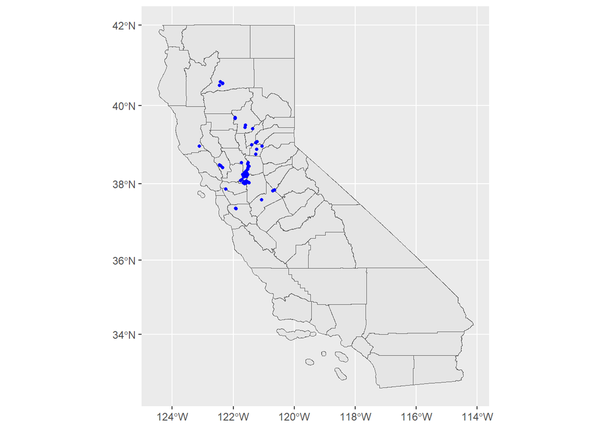

```r
ggplot() +
  geom_sf(data = ca_counties_sf) +
  geom_sf(data = sesbania_3857_sf, size = 1, color = "red")+
  geom_sf(data=sesbania_sf,size=1,color="blue")
```

## 2.4 Spatial join

How can I go about joining these data so that I can find counts by county? Don’t worry…`st_join()` has you covered for spatial joins!

```r
ca_sesb_sf <- ca_counties_sf %>%
  st_join(sesbania_3857_sf)

head(ca_sesb_sf)
```

```
Simple feature collection with 6 features and 10 fields
Geometry type: MULTIPOLYGON
Dimension:     XY
Bounding box:  xmin: -13565690 ymin: 4582029 xmax: -13358430 ymax: 4833572
Projected CRS: WGS 84 / Pseudo-Mercator
# A tibble: 6 × 11
  county land_km2                  geometry    id info_sourc last_updat presence
  <chr>     <dbl>        <MULTIPOLYGON [m]> <dbl> <chr>      <date>     <chr>
1 Sierra    2469. (((-13431320 4821511, -1…    NA <NA>       NA         <NA>
2 Sacra…    2499. (((-13490651 4680832, -1…     6 Steven Sc… 2002-10-07 Y
3 Sacra…    2499. (((-13490651 4680832, -1…    24 Robin Fal… 2003-09-17 Y
4 Sacra…    2499. (((-13490651 4680832, -1…    25 Robin Fal… 2003-09-17 Y
5 Sacra…    2499. (((-13490651 4680832, -1…    29 Robin Fal… 2003-09-17 Y
6 Sacra…    2499. (((-13490651 4680832, -1…    30 Robin Fal… 2003-09-17 Y
# ℹ 4 more variables: erad_work <chr>, location <chr>, watershed <chr>,
#   notes <chr>
```

Note: joining defaults to keeping the geometry of the first object, and adds the records of the second where they spatially overlap the first (but drops the geometry of the second). And then we can find counts (note: these are not counts for individual plants, but by record in the dataset) by county. We can’t just count the rows (e.g., using count()) because some rows are counties with no records (and sesbania information is all NAs).

We can also join the other direction:

```r
sesb_counties_sf <- sesbania_3857_sf %>%
  st_join(ca_counties_sf)

head(sesb_counties_sf)
```

```
Simple feature collection with 6 features and 10 fields
Geometry type: POINT
Dimension:     XY
Bounding box:  xmin: -13631670 ymin: 4553127 xmax: -13436540 ymax: 4733287
Projected CRS: WGS 84 / Pseudo-Mercator
# A tibble: 6 × 11
     id info_sourc        last_updat presence erad_work location watershed notes
  <dbl> <chr>             <date>     <chr>    <chr>     <chr>    <chr>     <chr>
1     5 Jason Guignard    2004-04-03 Y        Y         Wilms P… Stanisla… Abou…
2     6 Steven Scott      2002-10-07 Y        N         Morriso… Sacramen… Appr…
3     7 Carolyn Chainey-… 2002-10-29 Y        N         Rock Cr… Bear Riv… The …
4     8 Carolyn Chainey-… 2002-10-29 Y        N         Rock Cr… Bear Riv… <NA>
5     9 Jake Ruygt        2002-11-22 Y        N         South o… Napa Cou… Nume…
6    10 Jake Ruygt        1992-06-01 Y        N         Near Yo… Napa Riv… One …
# ℹ 3 more variables: geom <POINT [m]>, county <chr>, land_km2 <dbl>
```

This one keeps the point geometry of the plant records, but appends the county name and area from the CA map.

## 2.5 Summarize observations by county

Use the CA polygons`sf` object with the CA polygons to summarize the total number of sesbania in each. Watch out for `NAs`!

```r
sesb_counts_sf <- ca_sesb_sf %>%
  group_by(county) %>%
  summarize(n_records = sum(!is.na(id)))

head(sesb_counts_sf)
```

```
Simple feature collection with 6 features and 2 fields
Geometry type: MULTIPOLYGON
Dimension:     XY
Bounding box:  xmin: -13668380 ymin: 4502606 xmax: -13307390 ymax: 4888059
Projected CRS: WGS 84 / Pseudo-Mercator
# A tibble: 6 × 3
  county    n_records                                                   geometry
  <chr>         <int>                                         <MULTIPOLYGON [m]>
1 Alameda           1 (((-13612247 4538150, -13612347 4538291, -13612423 453844…
2 Alpine            0 (((-13366504 4678946, -13366493 4678954, -13366468 467897…
3 Amador            0 (((-13472698 4647652, -13472698 4647677, -13472698 464775…
4 Butte             5 (((-13565005 4798394, -13564992 4798529, -13565000 479854…
5 Calaveras         0 (((-13428575 4627725, -13428535 4627889, -13428535 462809…
6 Colusa            0 (((-13589905 4781178, -13589881 4781178, -13589804 478117…
```

Then we can plot a choropleth using the number of records for red sesbania as the fill color (instead of what we used previously, land area):

Make a choropleth map (filled in spatial map) using the number of records for red sesbania as the fill color (instead of what we used previously, land area):

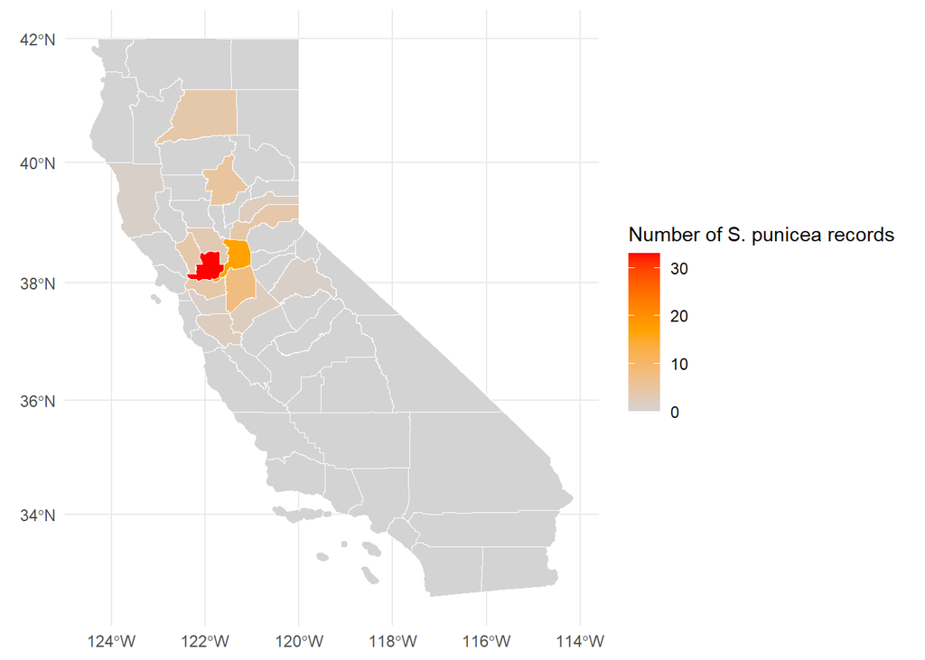

```r
ggplot(data = sesb_counts_sf) +
  geom_sf(aes(fill = n_records), color = "white", size = 0.1) +
  scale_fill_gradientn(colors = c("lightgray","orange","red")) +
  theme_minimal() +
  labs(fill = "Number of S. punicea records")
```

Now, on your own let’s practice our spatial data wrangling!

Only plot the county with the greatest number of red sesbania records, and make a map of those locations.

Hint: It’s okay to break the steps apart, you don’t need to do them all in one step (in fact it’s probably preferred you don’t).

### 2.5.1 Pseudocode here!

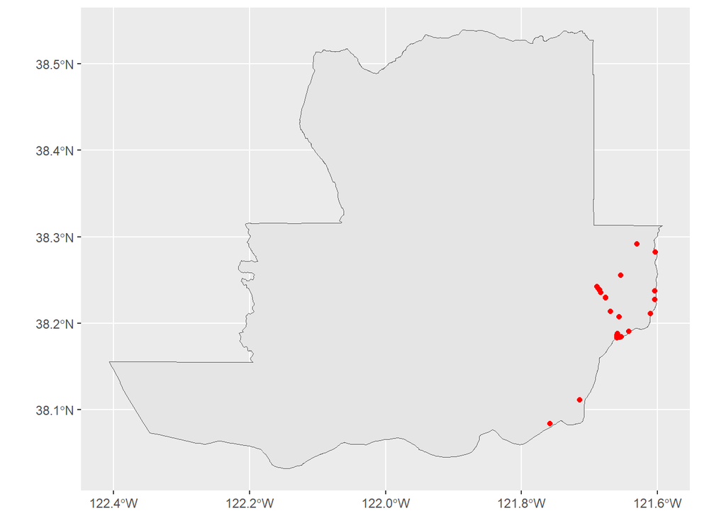

```r
# Subset of sesbania point locations only in Solano County

county_max <- sesb_counts_sf %>%
  filter(n_records == max(n_records)) %>%
  pull(county)

### we appended the county names to Sesbania records earlier:
solano_sesb_sf <- sesb_counties_sf %>%
  filter(county == county_max) ### what if two counties had the same max value?

# Only keep Solano polygon from California County data
solano_sf <- ca_counties_sf %>%
  filter(county %in% county_max)

ggplot() +
  geom_sf(data = solano_sf) +
  geom_sf(data = solano_sesb_sf, color = 'red')
```